# Assignment-4

Pawanjeet Kaur

11/15/2019

### Question:1 Draw an example (of your own invention) of a partition of two- dimensional feature space that could result from recursive binary splitting. Your example should contain at least six regions. Draw a decision tree corresponding to this partition. Be sure to label all as- pects of your figures, including the regions R1, R2, . . ., the cutpoints t1,t2,…, and so forth.

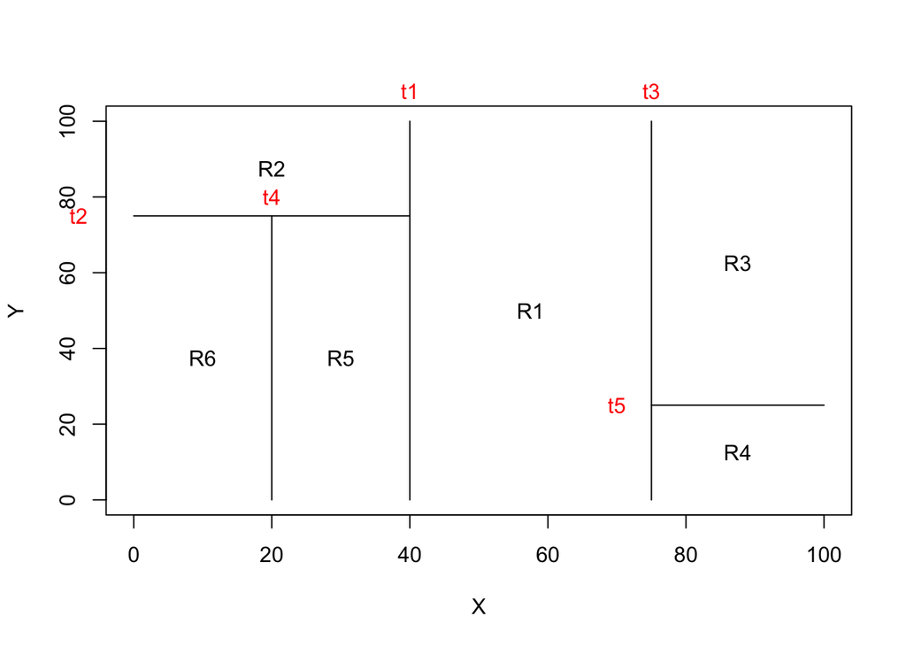

```r
par(xpd = NA)
plot(NA, NA, type = "n", xlim = c(0, 100), ylim = c(0, 100), xlab = "X", ylab = "Y")
# t1: x = 40; (40, 0) (40, 100)
lines(x = c(40, 40), y = c(0, 100))
text(x = 40, y = 108, labels = c("t1"), col = "red")
# t2: y = 75; (0, 75) (40, 75)
lines(x = c(0, 40), y = c(75, 75))
text(x = -8, y = 75, labels = c("t2"), col = "red")
# t3: x = 75; (75,0) (75, 100)
lines(x = c(75, 75), y = c(0, 100))
text(x = 75, y = 108, labels = c("t3"), col = "red")
# t4: x = 20; (20,0) (20, 75)
lines(x = c(20, 20), y = c(0, 75))
text(x = 20, y = 80, labels = c("t4"), col = "red")
# t5: y=25; (75,25) (100,25)
lines(x = c(75, 100), y = c(25, 25))
text(x = 70, y = 25, labels = c("t5"), col = "red")

text(x = (40 + 75)/2, y = 50, labels = c("R1"))
text(x = 20, y = (100 + 75)/2, labels = c("R2"))
text(x = (75 + 100)/2, y = (100 + 25)/2, labels = c("R3"))
text(x = (75 + 100)/2, y = 25/2, labels = c("R4"))
text(x = 30, y = 75/2, labels = c("R5"))
text(x = 10, y = 75/2, labels = c("R6"))
```

**DECISION TREE**

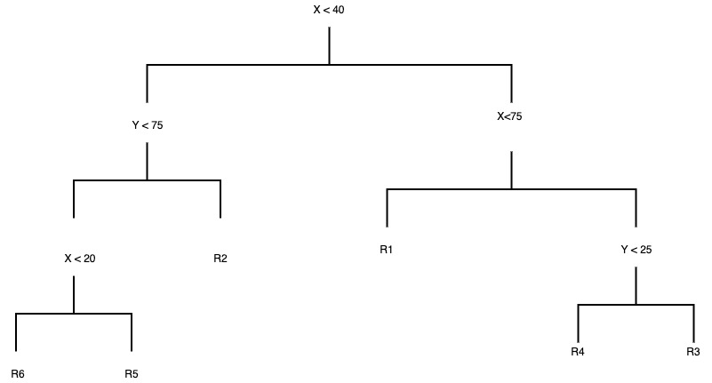

### Question 2: Consider the Gini index, classification error, and entropy in a simple classification setting with two classes. Create a single plot that displays each of these quantities as a functiono of pˆ(m-1) .The x-axis should display pˆm ranging from 0 to 1, and the y-axis the value of the Gini index, classification error, and entropy.

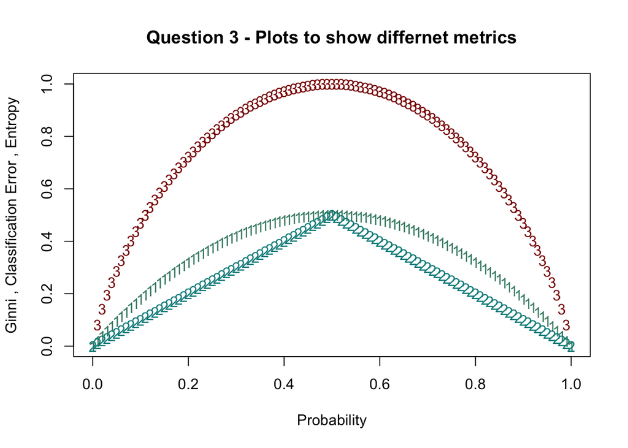

```r
# Step 1: create probability vector 0 -1 with 0.01 gap

p <- seq(0,1, 0.01)

ginni_index <- 2 * p * (1-p)

classification_error <- 1 - pmax(p, (1-p))

entropy <- - (p * log(p,2) + (1-p) * log((1-p),2))

# matplots are used to plot columns of a single matrix w.r.t single x values

matplot(p , cbind(ginni_index, classification_error, entropy),
        col = c("aquamarine4", "cyan4","darkred"),type = "b", xlab = "Probability",
        ylab = "Ginni , Classification Error , Entropy", main = "Question 3 - Plots to show differnet metrics")
```

### Question 3:

### (a) Split the data set into a training set and a test set.

```r
library(ISLR)

attach(Carseats)
set.seed(1990)

library(caTools)
split = sample.split(Carseats,SplitRatio = 0.80)

train_data=subset(Carseats, split==TRUE)
test_data=subset(Carseats, split==FALSE)
```

### (b) Fit a regression tree to the training set. Plot the tree, and inter- pret the results. What test MSE do you obtain?

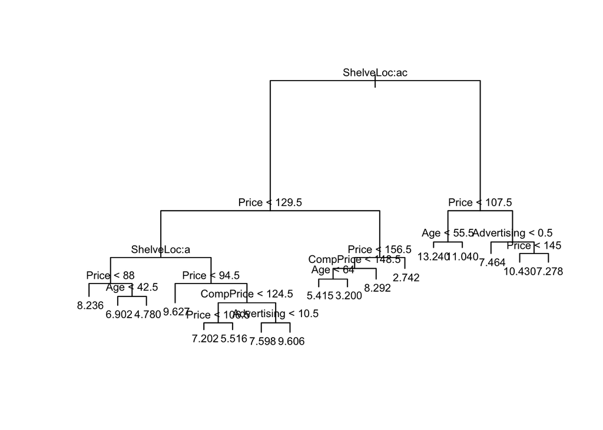

```r
library(tree)
reg_tree <- tree(formula = Sales ~., data = train_data)

plot(reg_tree)
text(reg_tree, cex= .75)
```

```r
test_predict <- predict(reg_tree, test_data)

mean_square_error <- mean((test_predict - test_data$Sales)^2)

mean_square_error
```

```
## [1] 4.606519
```

### (c) Use cross-validation in order to determine the optimal level of tree complexity. Does pruning the tree improve the test MSE?

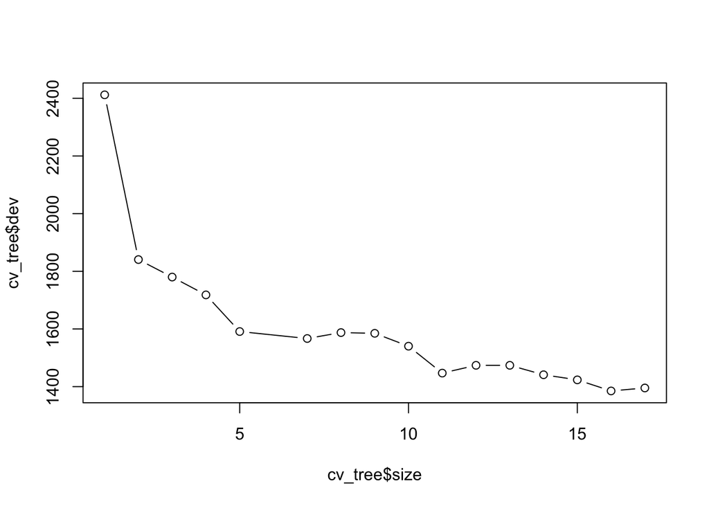

```r
cv_tree <- cv.tree(reg_tree)
plot(cv_tree$size ,cv_tree$dev ,type='b')
```

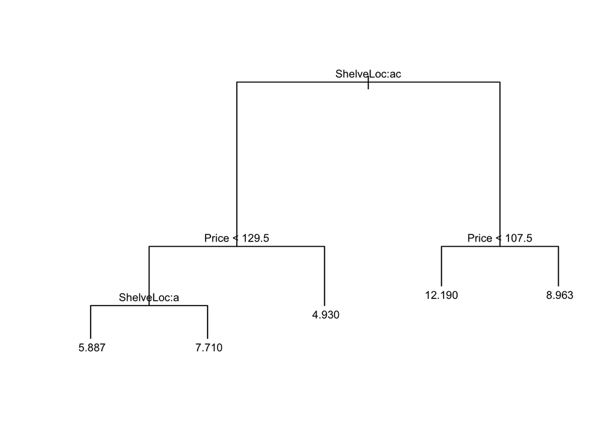

```r
pruned_tree <- prune.tree(reg_tree, best=5)
plot(pruned_tree)
text(pruned_tree, cex = 0.75)
```

```r
test_predict_2 <- predict(pruned_tree, test_data)
mean_square_error_2 <- mean((test_predict_2 - test_data$Sales)^2)

mean_square_error_2
```

```
## [1] 5.080278
```

**MSE increases after pruning the tree, so we use unpruned tree for further work**

### (d) Use the bagging approach in order to analyze this data. What test MSE do you obtain? Use the importance() function to de- termine which variables are most important.

**Bagging is special case of random forest with m = p**

```r
library(randomForest)
```

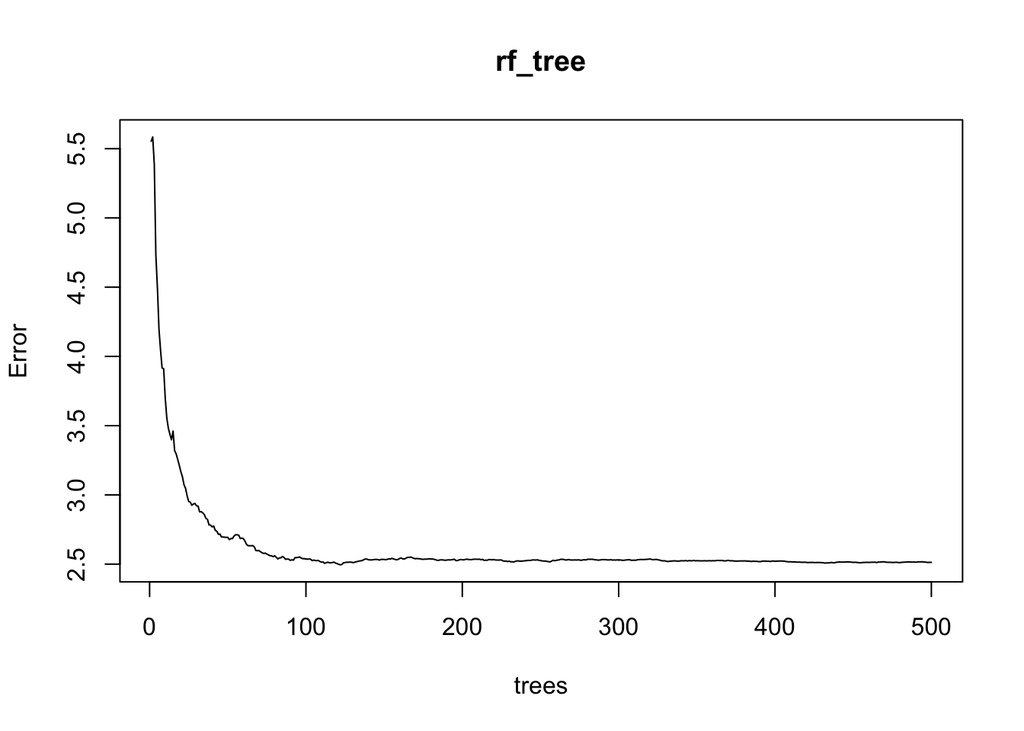

```r
rf_tree <- randomForest(Sales ~. , data= train_data, mtry = ncol(train_data)-1 ,importance= TRUE)

plot(rf_tree)
```

```r
summary(rf_tree)
```

```
##                 Length Class  Mode
## call              5    -none- call
## type              1    -none- character
## predicted       290    -none- numeric
## mse             500    -none- numeric
## rsq             500    -none- numeric
## oob.times       290    -none- numeric
## importance       20    -none- numeric
## importanceSD     10    -none- numeric
## localImportance   0    -none- NULL
## proximity         0    -none- NULL
## ntree             1    -none- numeric
## mtry              1    -none- numeric
## forest           11    -none- list
## coefs             0    -none- NULL
## y               290    -none- numeric
## test              0    -none- NULL
## inbag             0    -none- NULL
## terms             3    terms  call
```

```r
test_predict_3 <- predict(rf_tree, test_data)
mean_square_error_3 <- mean((test_predict_3 - test_data$Sales)^2)

mean_square_error_3
```

```
## [1] 2.253843
```

```r
importance(rf_tree)
```

```
##               %IncMSE IncNodePurity
## CompPrice   30.205235    216.941758
## Income      12.534205    125.246632
## Advertising 19.077555    137.381523
## Population   1.640638     79.161701
## Price       61.333597    706.271647
## ShelveLoc   77.649047    757.685502
## Age         17.045750    174.250572
## Education    7.566428     81.639025
## Urban       -3.450285      9.685185
## US           5.633160     19.381628
```

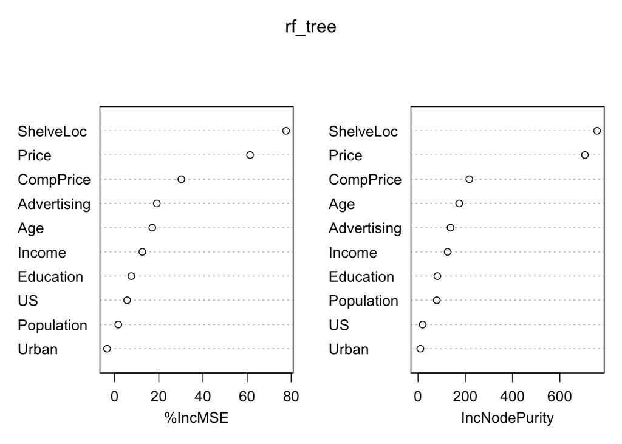

```r
varImpPlot(rf_tree)
```

### (e) Use random forests to analyze this data. What test MSE do you obtain? Use the importance() function to determine which vari- ables are most important. Describe the effect of m, the number of variables considered at each split, on the error rate obtained.

**rf uses by default sqrt(p) as value of m for classification and p/3 for regression**

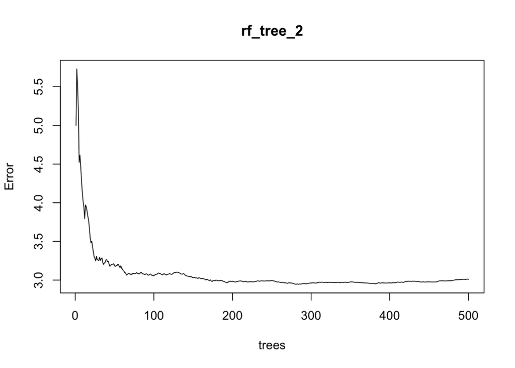

```r
library(randomForest)

rf_tree_2 <- randomForest(Sales ~. , data= train_data, mtry = sqrt(ncol(train_data)) ,importance= TRUE)

plot(rf_tree_2)
```

```r
summary(rf_tree_2)
```

```
##                 Length Class  Mode
## call              5    -none- call
## type              1    -none- character
## predicted       290    -none- numeric
## mse             500    -none- numeric
## rsq             500    -none- numeric
## oob.times       290    -none- numeric
## importance       20    -none- numeric
## importanceSD     10    -none- numeric
## localImportance   0    -none- NULL
## proximity         0    -none- NULL
## ntree             1    -none- numeric
## mtry              1    -none- numeric
## forest           11    -none- list
## coefs             0    -none- NULL
## y               290    -none- numeric
## test              0    -none- NULL
## inbag             0    -none- NULL
## terms             3    terms  call
```

```r
test_predict_4 <- predict(rf_tree_2, test_data)
mean_square_error_4 <- mean((test_predict_4 - test_data$Sales)^2)

mean_square_error_4
```

```
## [1] 2.601828
```

```r
importance(rf_tree_2)
```

```
##                 %IncMSE IncNodePurity
## CompPrice   13.56953829     212.44017
## Income       6.29408368     180.33203
## Advertising  9.94546041     157.40606
## Population  -0.45897488     140.34329
## Price       41.76717824     553.28001
## ShelveLoc   48.57880615     577.41898
## Age         10.40045285     235.72972
## Education    3.60265025     117.16964
## Urban       -0.00726031      19.61157
## US           3.36933679      31.56008
```

```r
varImpPlot(rf_tree_2)

error_list <- list()

for( i in seq(1: ncol(Carseats))) {
  rf_tree_2 <- randomForest(Sales ~. , data= train_data, mtry = i ,importance= TRUE)

  test_predict_4 <- predict(rf_tree_2, test_data)
  mean_square_error_4 <- mean((test_predict_4 - test_data$Sales)^2)

  error_list[i] <- mean_square_error_4
  importance(rf_tree_2)
}
length(error_list)
```

```
## [1] 11
```

[figure not shown]

```r
library(ggplot2)
```

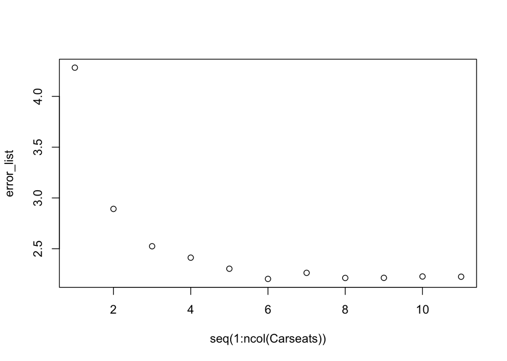

```r
df <- data.frame(seq(1:ncol(Carseats)), error_list)
plot(seq(1:ncol(Carseats)) ,y = error_list)
```

### Question 4:

### (a) Remove the observations for whom the salary information is unknown, and then log-transform the salaries.

```r
library(ISLR)

attach(Hitters)
dim(Hitters)
```

```
## [1] 322  20
```

```r
new_data <- Hitters[!is.na(Salary),]
dim(new_data)
```

```
## [1] 263  20
```

```r
new_data$Salary <- log(new_data$Salary)
```

### (b) Create a training set consisting of the first 200 observations, and a test set consisting of the remaining observations.

```r
train_data <- new_data[1:200, ]
test_data <- new_data[-(1:200),]
```

### (c) Perform boosting on the training set with 1,000 trees for a range of values of the shrinkage parameter λ. Produce a plot with different shrinkage values on the x-axis and the corresponding training set MSE on the y-axis.

```r
library(gbm)
```

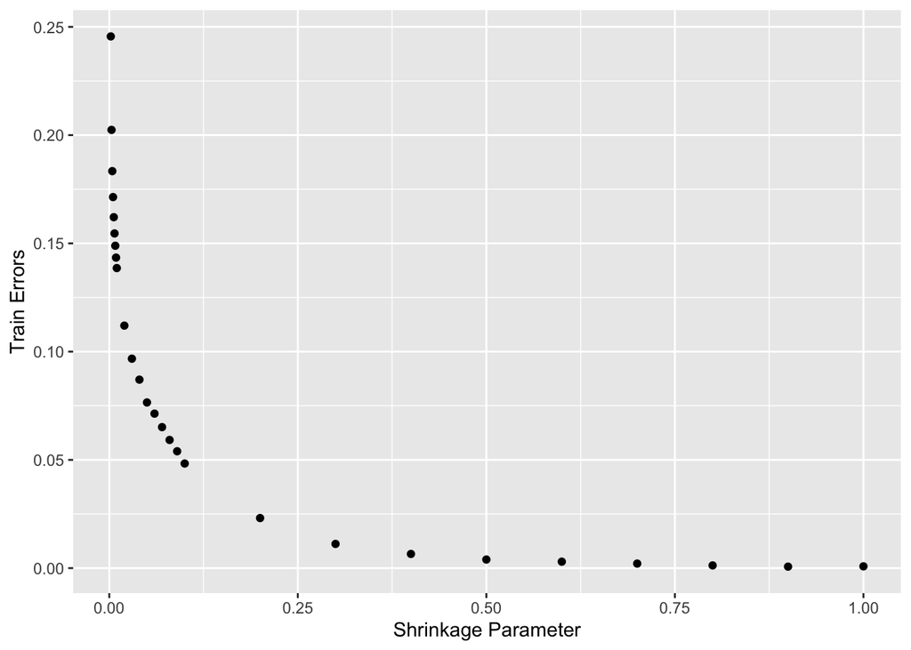

```r
lambda_values <- c(c(), seq(0.002, 0.01, by=0.001))
lambda_values <- c(lambda_values, seq(0.02, 0.1, by=0.01))
lambda_values <- c(lambda_values, seq(0.2, 1, by=0.1))

train_errors <- rep(NA, length(lambda_values))
test_errors <- rep(NA, length(lambda_values))

for(i in 1:length(lambda_values)) {
  boost_model=gbm(Salary~.,data=train_data,distribution="gaussian",n.trees=1000, shrinkage = lambda_values[i])
  train_predict <- predict(boost_model , train_data, n.trees = 1000)
  test_predict <- predict(boost_model , test_data, n.trees = 1000)

  mean_square_train_error <- mean((train_predict - train_data$Salary)^2)
  train_errors[i] <- mean_square_train_error
  mean_square_test_error <- mean((test_predict - test_data$Salary)^2)
  test_errors[i] <- mean_square_test_error
}

library(ggplot2)

ggplot(data = data.frame(x = lambda_values ,y = train_errors) , aes(x=x, y=y)) + xlab("Shrinkage Parameter") + ylab("Train Errors") + geom_point()
```

### (d) Produce a plot with different shrinkage values on the x-axis and the corresponding test set MSE on the y-axis.

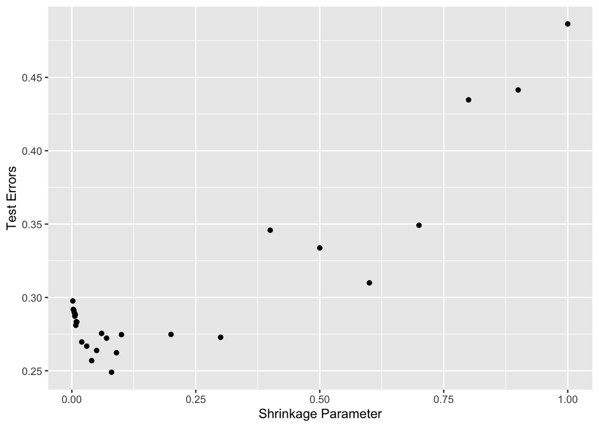

```r
ggplot(data = data.frame(x = lambda_values ,y = test_errors) , aes(x=x, y=y)) + xlab("Shrinkage Parameter") + ylab("Test Errors") + geom_point()
```

### (e) Compare the test MSE of boosting to the test MSE that results from applying two of the regression approaches seen in Chapters 3 and 6.

```r
#chapter 3 : Linear Regression Chapter 6: Ridge and Lasso
lm_model <- lm(formula = train_data$Salary~. , data = train_data)

lm_predict <- predict(lm_model, test_data)
mean_sq_err_lm <- mean((lm_predict - test_data$Salary)^2)

mean_sq_err_lm
```

```
## [1] 0.4917959
```

```r
# Lasso alpha=1 Ridge alpha = 0
str(train_data)
```

```
## 'data.frame':    200 obs. of  20 variables:
##  $ AtBat    : int  315 479 496 321 594 185 298 323 401 574 ...
##  $ Hits     : int  81 130 141 87 169 37 73 81 92 159 ...
##  $ HmRun    : int  7 18 20 10 4 1 0 6 17 21 ...
##  $ Runs     : int  24 66 65 39 74 23 24 26 49 107 ...
##  $ RBI      : int  38 72 78 42 51 8 24 32 66 75 ...
##  $ Walks    : int  39 76 37 30 35 21 7 8 65 59 ...
##  $ Years    : int  14 3 11 2 11 2 3 2 13 10 ...
##  $ CAtBat   : int  3449 1624 5628 396 4408 214 509 341 5206 4631 ...
##  $ CHits    : int  835 457 1575 101 1133 42 108 86 1332 1300 ...
##  $ CHmRun   : int  69 63 225 12 19 1 0 6 253 90 ...
##  $ CRuns    : int  321 224 828 48 501 30 41 32 784 702 ...
##  $ CRBI     : int  414 266 838 46 336 9 37 34 890 504 ...
##  $ CWalks   : int  375 263 354 33 194 24 12 8 866 488 ...
##  $ League   : Factor w/ 2 levels "A","N": 2 1 2 2 1 2 1 2 1 1 ...
##  $ Division : Factor w/ 2 levels "E","W": 2 2 1 1 2 1 2 2 1 1 ...
##  $ PutOuts  : int  632 880 200 805 282 76 121 143 0 238 ...
##  $ Assists  : int  43 82 11 40 421 127 283 290 0 445 ...
##  $ Errors   : int  10 14 3 4 25 7 9 19 0 22 ...
##  $ Salary   : num  6.16 6.17 6.21 4.52 6.62 ...
##  $ NewLeague: Factor w/ 2 levels "A","N": 2 1 2 2 1 1 1 2 1 1 ...
```

```r
library(glmnet)
x_reg_train <- as.matrix(train_data[, -c(14,15,20,19)])
y_reg_train <- as.matrix(train_data[, 19])

x_reg_test <- as.matrix(test_data[, -c(14,15,20,19)])
y_reg_test <- as.matrix(test_data[, 19])

ridge_model_val <- cv.glmnet(x_reg_train , y_reg_train, alpha = 0)
ridge_model_val
```

```
##
## Call:  cv.glmnet(x = x_reg_train, y = y_reg_train, alpha = 0)
##
## Measure: Mean-Squared Error
##
##     Lambda Measure      SE Nonzero
## min 0.0578  0.3990 0.05200      16
## 1se 3.1584  0.4475 0.03568      16
```

```r
ridge_model <- glmnet(x_reg_train , y_reg_train, alpha = 0, lambda = ridge_model_val$lambda.min)
ridge_model
```

```
##
## Call:  glmnet(x = x_reg_train, y = y_reg_train, alpha = 0, lambda = ridge_model_val$lambda.min)
##
##   Df   %Dev  Lambda
## 1 16 0.5827 0.05782
```

```r
ridge_predict <- predict(ridge_model, x_reg_test)
mean_sq_err_ridge <- mean((ridge_predict - test_data$Salary)^2)

mean_sq_err_ridge
```

```
## [1] 0.4736074
```

```r
lasso_model <- glmnet(x_reg_train , y_reg_train, alpha = 1)
lasso_predict <- predict(lasso_model, x_reg_test)
mean_sq_err_lasso <- mean((lasso_predict - test_data$Salary)^2)

mean_sq_err_lasso
```

```
## [1] 0.4896433
```

### (f) Which variables appear to be the most important predictors in the boosted model?

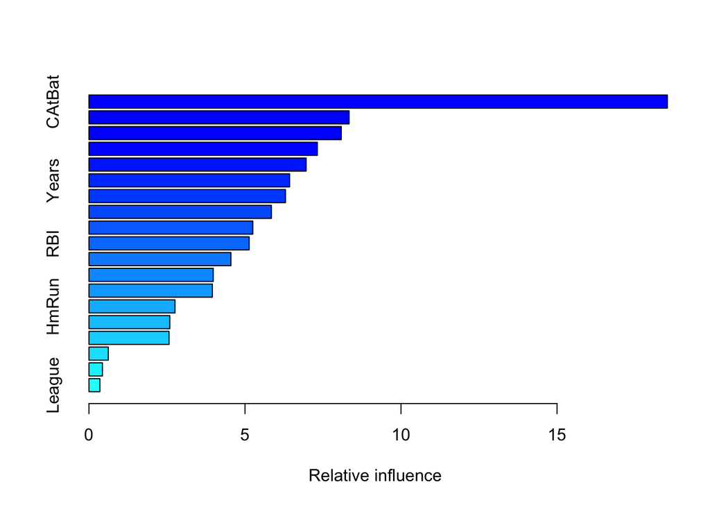

```
##                 var    rel.inf
## CAtBat       CAtBat 18.5363795
## PutOuts     PutOuts  8.3365573
## CHits         CHits  8.0851317
## CRBI           CRBI  7.3189840
## CWalks       CWalks  6.9596807
## Years         Years  6.4309589
## Walks         Walks  6.2983968
## CRuns         CRuns  5.8467062
## CHmRun       CHmRun  5.2503668
## RBI             RBI  5.1342625
## AtBat         AtBat  4.5498723
## Hits           Hits  3.9824889
## Assists     Assists  3.9552363
## HmRun         HmRun  2.7578125
## Errors       Errors  2.5912605
## Runs           Runs  2.5660805
## Division   Division  0.6186730
## NewLeague NewLeague  0.4311010
## League       League  0.3500506
```

```r
best_boosted_model <- gbm(Salary~.,data=train_data,distribution="gaussian",
                          n.trees=1000, shrinkage =lambda_values[which.min(test_errors)])
summary(best_boosted_model)
```

### (g) Now apply bagging to the training set. What is the test set MSE for this approach?

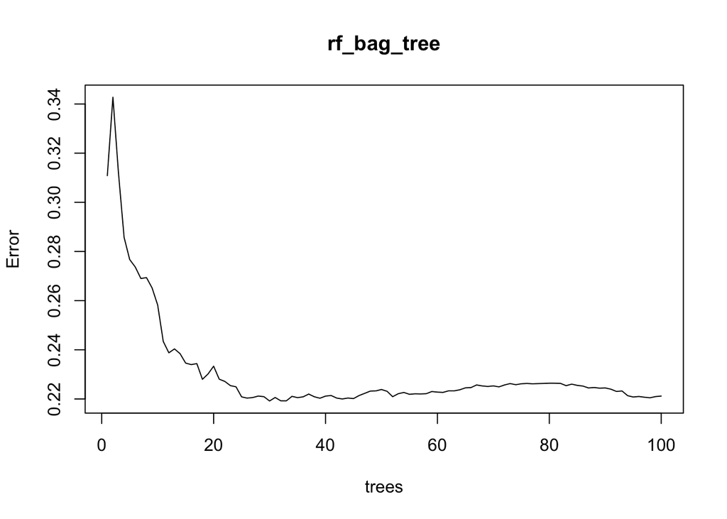

```r
library(randomForest)

rf_bag_tree <- randomForest(Salary ~. , data= train_data, ntree= 100, mtry = ncol(train_data)-1 ,importance= TRUE)

plot(rf_bag_tree)
```

```r
summary(rf_bag_tree)
```

```
##                 Length Class  Mode
## call              6    -none- call
## type              1    -none- character
## predicted       200    -none- numeric
## mse             100    -none- numeric
## rsq             100    -none- numeric
## oob.times       200    -none- numeric
## importance       38    -none- numeric
## importanceSD     19    -none- numeric
## localImportance   0    -none- NULL
## proximity         0    -none- NULL
## ntree             1    -none- numeric
## mtry              1    -none- numeric
## forest           11    -none- list
## coefs             0    -none- NULL
## y               200    -none- numeric
## test              0    -none- NULL
## inbag             0    -none- NULL
## terms             3    terms  call
```

```r
test_predict_rf_bag <- predict(rf_bag_tree, test_data)
test_predict_rf_bag
```

[output not shown]

```r
mean_square_error_rf_bag <- mean((test_predict_rf_bag - test_data$Salary)^2)

mean_square_error_rf_bag
```

```
## [1] 0.2311746
```

### Question 5:

### (a) We are given n = 7 observations in p = 2 dimensions. For each observation, there is an associated class label.

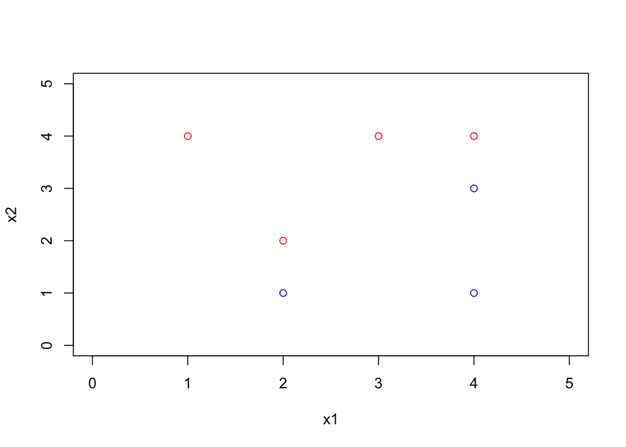

```r
x1 <- c(3,2,4,1,2,4,4)
x2 <- c(4,2,4,4,1,3,1)

y <- c("Red","Red","Red","Red","Blue", "Blue", "Blue")

data <- data.frame(x1,x2,y)
plot(x1, x2, col = y, xlim = c(0,5), ylim = c(0,5))
```

### (b) Sketch the optimal separating hyperplane, and provide the equation for this hyperplane (of the form (9.1)).

**Based on the graph points dividing two classes- (2,1.5) , (4,3.5)** **Equation: x2 - 3.5 = ((3.5 - 1.5)/(4-2)) (x1 - 4) => x2 -3.5 = x1 -4 => x2 = x1 - 0.5**

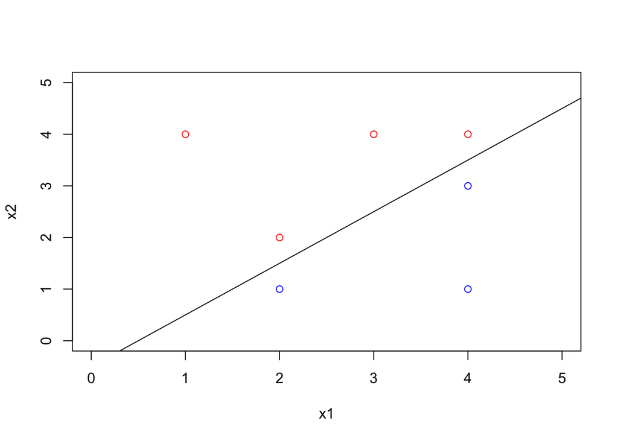

```r
slope = 1
intercept = -0.5
plot(x1, x2, col = y, xlim = c(0,5), ylim = c(0,5))
abline(intercept, slope)
```

```r
#library(e1071)

#svm.fit <- svm(formula=y~., data = data, kernel= "linear",scale= FALSE, method = "class")
#plot(svm.fit, data)
```

### (c) Describe the classification rule for the maximal margin classifier.It should be something along the lines of “Classify to Red if β0 + β1X1 + β2X2 > 0, and classify to Blue otherwise.” Provide the values for β0, β1, and β2.

**Answer β0 is intercept ( -0.5) and β1 -> 1 β2 <- -1 So equation : x1 - x2 - 0.5 < 0 Classify Red or else classify as blue**

### (d) On your sketch, indicate the margin for the maximal margin hyperplane

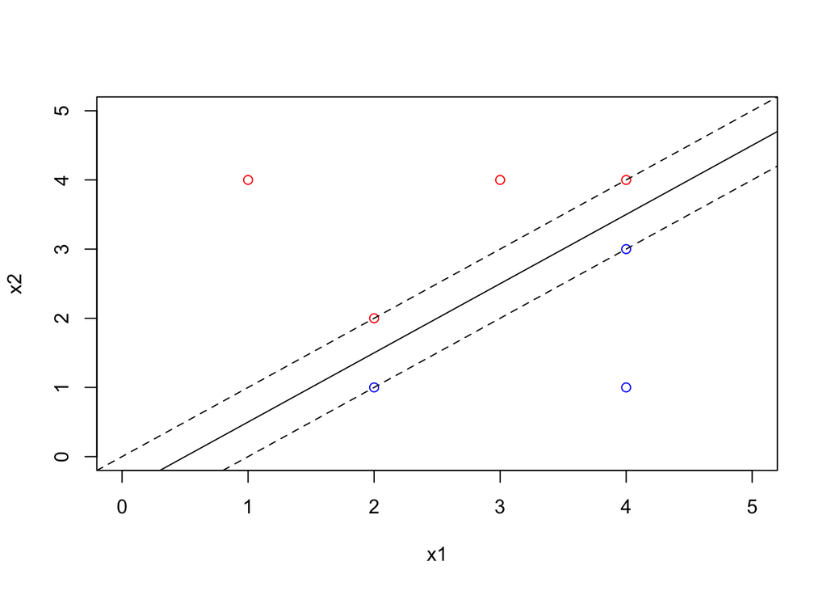

```r
plot(x1, x2, col = y, xlim = c(0,5), ylim = c(0,5))
abline(intercept, slope)
abline(intercept+0.5, slope, lty= 2)
abline(intercept-0.5, slope, lty=2)
```

### (e) Indicate the support vectors for the maximal margin classifier.

**The support vectors are the points (2,1), (2,2), (4,3) and (4,4)**

### (f) Argue that a slight movement of the seventh observation would not affect the maximal margin hyperplane.

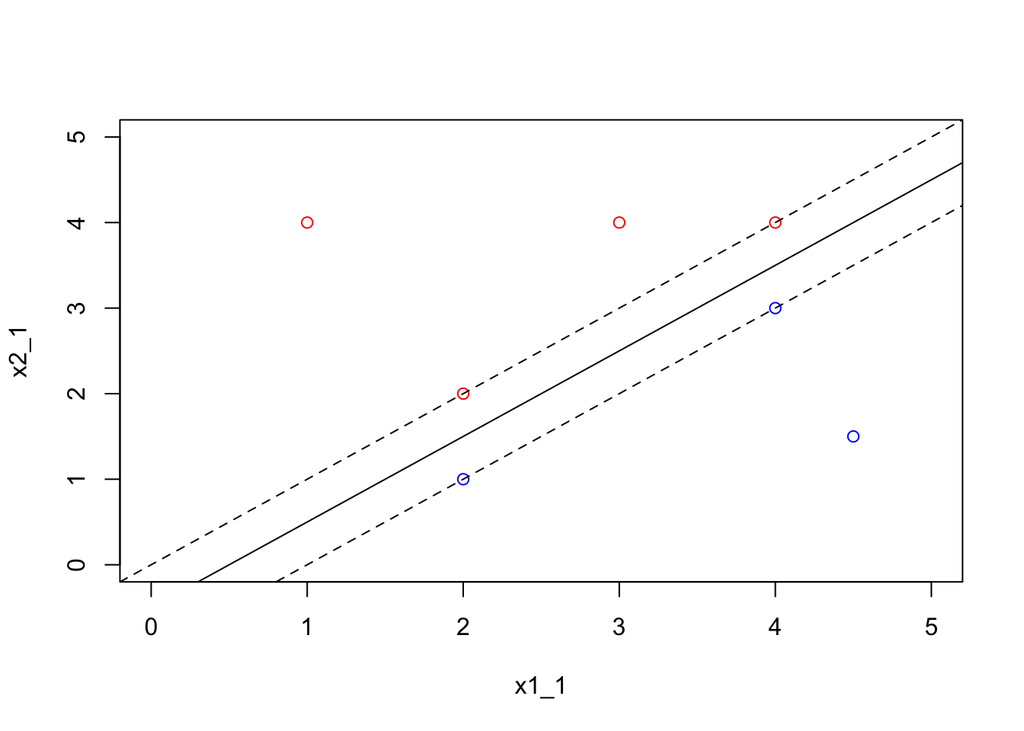

```r
x1_1 <- c(3,2,4,1,2,4,4.5)
x2_1 <- c(4,2,4,4,1,3,1.5)

y_1 <- c("Red","Red","Red","Red","Blue", "Blue", "Blue")

data_1 <- data.frame(x1_1,x2_1,y_1)
slope = 1
intercept = -0.5
plot(x1_1, x2_1, col = y_1, xlim = c(0,5), ylim = c(0,5))
abline(intercept, slope)
abline(intercept+0.5, slope, lty= 2)
abline(intercept-0.5, slope, lty=2)
```

**Above plot shows us that slight movement in last plot didnot make much difference on mazimal margin hyperplane**

### (g) Sketch a hyperplane that is not the optimal separating hyperplane, and provide the equation for this hyperplane.

Little swtich in the equation of hyperplane will give us the plane which is not the maximal margin plane.X1−X2−0.3=0 is one of plane which is not optimal plane.

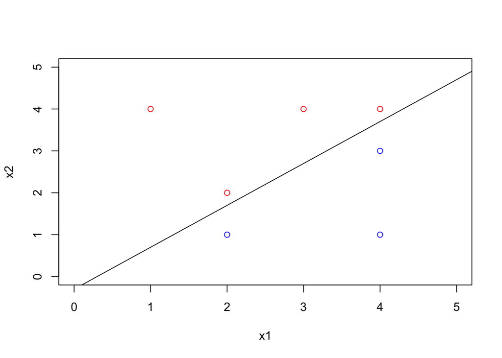

```r
plot(x1, x2, col = y, xlim = c(0, 5), ylim = c(0, 5))
abline(-0.3, 1)
```

```r
#Using svm method, if we provide a cost to function which is the cost of violation of the margin.with cost argument small we get wide margins and with large value we get narrow margins.

#svm.fit_1 <- svm(formula=y~., data = data,type= 'C-classification', kernel= "linear",scale= FALSE, method = "class", cost=1.5)
#plot(svm.fit_1, data)
```

### (h) Draw an additional observation on the plot so that the two classes are no longer separable by a hyperplane.

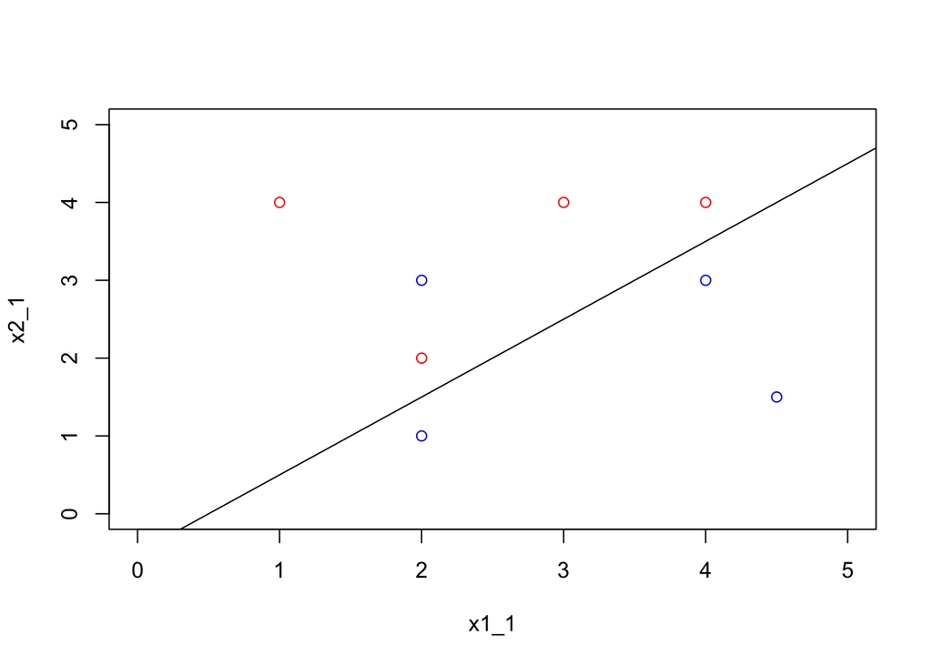

```r
x1_1 <- c(3,2,4,1,2,4,4.5,2)
x2_1 <- c(4,2,4,4,1,3,1.5,3)

y_1 <- c("Red","Red","Red","Red","Blue", "Blue", "Blue","Blue")

slope = 1
intercept = -0.5
plot(x1_1, x2_1, col = y_1, xlim = c(0,5), ylim = c(0,5))
abline(intercept, slope)
```